# An Introduction to Random Forests

## Heart data

Goal: Determine whether patient with chest pain has heart disease (`AHD`)

```r
heart <- read.csv("http://www-bcf.usc.edu/~gareth/ISL/Heart.csv")[,-1]
heart <- na.omit(heart)
glimpse(heart)
```

```
## Observations: 297
## Variables: 14
## $ Age       <int> 63, 67, 67, 37, 41, 56, 62, 57, 63, 53, 57, 56, 56, ...
## $ Sex       <int> 1, 1, 1, 1, 0, 1, 0, 0, 1, 1, 1, 0, 1, 1, 1, 1, 1, 1...
## $ ChestPain <fctr> typical, asymptomatic, asymptomatic, nonanginal, no...
## $ RestBP    <int> 145, 160, 120, 130, 130, 120, 140, 120, 130, 140, 14...
## $ Chol      <int> 233, 286, 229, 250, 204, 236, 268, 354, 254, 203, 19...
## $ Fbs       <int> 1, 0, 0, 0, 0, 0, 0, 0, 0, 1, 0, 0, 1, 0, 1, 0, 0, 0...
## $ RestECG   <int> 2, 2, 2, 0, 2, 0, 2, 0, 2, 2, 0, 2, 2, 0, 0, 0, 0, 0...
## $ MaxHR     <int> 150, 108, 129, 187, 172, 178, 160, 163, 147, 155, 14...
## $ ExAng     <int> 0, 1, 1, 0, 0, 0, 0, 1, 0, 1, 0, 0, 1, 0, 0, 0, 0, 0...
## $ Oldpeak   <dbl> 2.3, 1.5, 2.6, 3.5, 1.4, 0.8, 3.6, 0.6, 1.4, 3.1, 0....
## $ Slope     <int> 3, 2, 2, 3, 1, 1, 3, 1, 2, 3, 2, 2, 2, 1, 1, 1, 3, 1...
## $ Ca        <int> 0, 3, 2, 0, 0, 0, 2, 0, 1, 0, 0, 0, 1, 0, 0, 0, 0, 0...
## $ Thal      <fctr> fixed, normal, reversable, normal, normal, normal, ...
## $ AHD       <fctr> No, Yes, Yes, No, No, No, Yes, No, Yes, Yes, No, No...
```

## Baseline error

The worst our classifier can do is to classify all observations into the largest class

```r
ahd_tab <- table(heart$AHD)
ahd_tab
```

```
##
##  No Yes
## 160 137
```

```r
ahd_tab["Yes"] / sum(ahd_tab)
```

```
##       Yes
## 0.4612795
```

## Classification trees

- Grow a tree from your training set
- Prune the tree
- Use for classification

## Growing a tree

```r
set.seed(222)
train_index <- sample(1:nrow(heart), size = 200)
test_index <- setdiff(1:nrow(heart), train_index)
train <- heart[train_index,]
test <- heart[-train_index,]
```

```r
library(rpart)
heart_tree <- rpart(AHD ~ ., data = train)
table(prediction = predict(heart_tree, newdata = test, type = "class"),
      truth = test$AHD)
```

```
##           truth
## prediction No Yes
##        No  44  11
##        Yes 10  32
```

## What if we repeat?

```r
train_index2 <- sample(1:nrow(heart), size = 200)
test_index2 <- setdiff(1:nrow(heart), train_index2)
train2 <- heart[train_index2,]
test2 <- heart[-train_index2,]
```

```r
heart_tree2 <- rpart(AHD ~ ., data = train)
table(prediction = predict(heart_tree2, newdata = test2, type = "class"),
      truth = test2$AHD)
```

```
##           truth
## prediction No Yes
##        No  41   6
##        Yes  8  42
```

## Classification trees

| Advantages | Disadvantages |
| --- | --- |
| Easy to explain | Generally do not have the same level of predictive accuracy as many other classification approaches |
| May more closely mirror human decision-making than other approaches | High variability |
| Can be displayed graphically, and are easily interpreted even by a non-expert (especially if they are small) |  |
| Can easily handle categorical predictors without the need to create dummy variables |  |

## An improvement: Bootstrap aggregating

- Sample with replacement from your training data set
- Grow a tree for each bootstrap sample
- Majority (plurality) vote to classify an observation

## Bagging

```r
library(randomForest)
heart_bag <- randomForest(AHD ~ ., data = heart, mtry = 13)
heart_bag
```

```
##
## Call:
##  randomForest(formula = AHD ~ ., data = heart, mtry = 13)
##                Type of random forest: classification
##                      Number of trees: 500
## No. of variables tried at each split: 13
##
##         OOB estimate of  error rate: 19.53%
## Confusion matrix:
##      No Yes class.error
## No  133  27   0.1687500
## Yes  31 106   0.2262774
```

## Estimating test error

- Each tree contains ~ 2/3 of the observations, on average
- Out-of-bag (OOB) observations: the remaining ~1/3 of observations
- Test error: Predict the class of each observations only using trees for which that observation is OOB

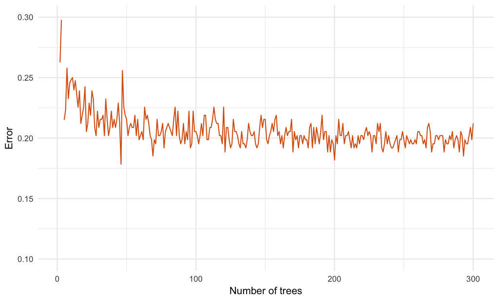

## Pitfalls

- If there is a particularly strong attribute in the data set, the trees may all use that attribute as the top split
- Resulting trees are highly correlated, which leads to less improvement over a single tree

## Another improvement: Random forests

- Sample with replacement from your training data set
- Grow a tree for each bootstrap sample
  - For each split only consider m out of p attributes
  - Select the best attribute and partition the data
- Majority (plurality) vote to classify an observation

```r
# By default, mtry = sqrt(p)
heart_rf <- randomForest(AHD ~ ., data = heart)
heart_rf
```

```
##
## Call:
##  randomForest(formula = AHD ~ ., data = heart)
##                Type of random forest: classification
##                      Number of trees: 500
## No. of variables tried at each split: 3
##
##         OOB estimate of  error rate: 18.86%
## Confusion matrix:
##      No Yes class.error
## No  135  25   0.1562500
## Yes  31 106   0.2262774
```

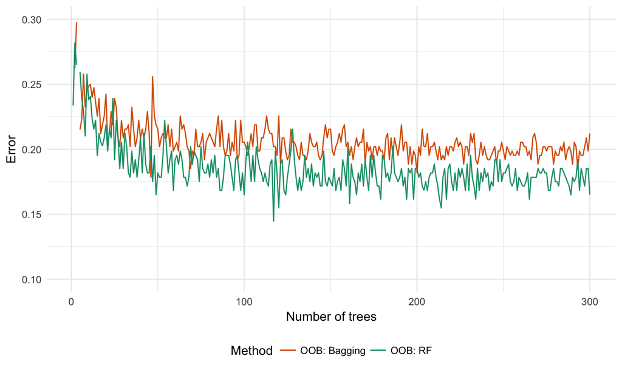

## Interpretability of forests

A voting scheme across hundreds of trees is hard to interpret… but we can see which variables are important

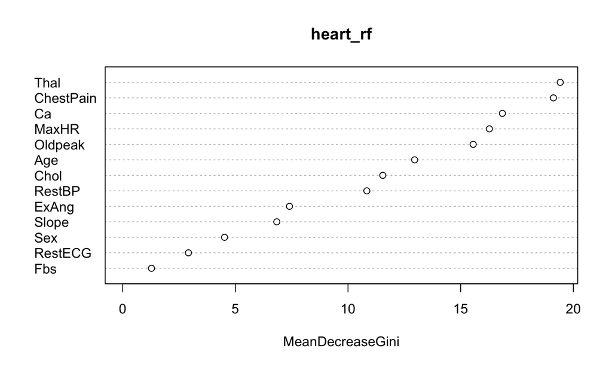

```r
varImpPlot(heart_rf)
```